# ejercicio_5

```python
import pandas as pd
import numpy as np
```

🔹 Ejercicio 1: Análisis de Datos con NumPy Crea una matriz de 10x10 con valores aleatorios enteros entre 50 y 500 y realiza las siguientes tareas:

1. Encuentra los valores máximos y mínimos en cada fila.
2. Calcula el promedio de cada columna.
3. Convierte los valores de la matriz en logaritmo natural (np.log).
4. Reemplaza todos los valores mayores a 400 por el promedio de la matriz.

📌 Ejemplo de salida esperada:

- Valores máximos por fila: [...]
- Valores mínimos por fila: [...]
- Promedio de cada columna: [...]
- Matriz transformada con logaritmo natural:
- [[..., ..., ...], [..., ..., ...], ...]

```python
# Crear una matriz de 10x10 valores entre 50 y 500
matriz = np.random.randint(50, 501, size=(10,10))
matriz
```

```
array([[347, 211, 176, 218, 486, 171, 344, 329, 290, 245],
       [180, 414, 139, 319, 444,  57, 181, 379, 322, 302],
       [ 90, 388, 452, 490, 438,  53, 168, 215, 353,  97],
       [252, 215,  57, 268, 453, 189,  58, 394, 210, 183],
       [278, 297, 124, 273, 438, 259, 118, 315, 113, 482],
       [125, 309, 285, 135, 484, 409, 393, 162,  88, 229],
       [458, 496, 233, 349,  51,  72, 123, 373, 268,  65],
       [129, 181, 372, 367, 121, 298, 499, 145, 351, 290],
       [301, 385, 353, 284, 238, 154,  73, 123, 312, 356],
       [312, 297, 229, 383, 466, 288, 485, 369, 379, 488]], dtype=int32)
```

```python
# Encontrar los valores máximos y mínimos de cada fila
mas_fila = matriz.max(axis=1)
min_fila = matriz.min(axis=1)

print(f'Valores maximos de cada fila: {mas_fila}')
print(f'Valores minimos de cada fila: {min_fila}')
```

```
Valores maximos de cada fila: [486 444 490 453 482 484 496 499 385 488]
Valores minimos de cada fila: [171  57  53  57 113  88  51 121  73 229]
```

```python
# Promedio de cada columna
prom_columnas = matriz.mean(axis=0)
print(f'Promedio de cada columna: {prom_columnas}')
```

```
Promedio de cada columna: [247.2 319.3 242.  308.6 361.9 195.  244.2 280.4 268.6 273.7]
```

```python
# Convierte los valores de la matriz en logaritmo natural (np.log)
matriz_log = np.log(matriz)
matriz_log
```

```
array([[5.84932478, 5.35185813, 5.170484  , 5.38449506, 6.18620862,
        5.14166356, 5.84064166, 5.79605775, 5.66988092, 5.50125821],
       [5.19295685, 6.02586597, 4.93447393, 5.7651911 , 6.09582456,
        4.04305127, 5.19849703, 5.93753621, 5.77455155, 5.71042702],
       [4.49980967, 5.96100534, 6.11368218, 6.19440539, 6.08221891,
        3.97029191, 5.12396398, 5.37063803, 5.86646806, 4.57471098],
       [5.52942909, 5.37063803, 4.04305127, 5.59098698, 6.11589213,
        5.24174702, 4.06044301, 5.97635091, 5.34710753, 5.20948615],
       [5.62762111, 5.69373214, 4.82028157, 5.6094718 , 6.08221891,
        5.55682806, 4.77068462, 5.75257264, 4.72738782, 6.17794411],
       [4.82831374, 5.73334128, 5.65248918, 4.90527478, 6.18208491,
        6.01371516, 5.97380961, 5.08759634, 4.47733681, 5.433722  ],
       [6.12686918, 6.20657593, 5.45103845, 5.85507192, 3.93182563,
        4.27666612, 4.81218436, 5.92157842, 5.59098698, 4.17438727],
       [4.8598124 , 5.19849703, 5.91889385, 5.90536185, 4.79579055,
        5.69709349, 6.2126061 , 4.97673374, 5.86078622, 5.66988092],
       [5.70711026, 5.95324333, 5.86646806, 5.64897424, 5.47227067,
        5.0369526 , 4.29045944, 4.81218436, 5.74300319, 5.87493073],
       [5.74300319, 5.69373214, 5.433722  , 5.94803499, 6.14418563,
        5.66296048, 6.18414889, 5.91079664, 5.93753621, 6.19031541]])
```

```python
# Remplazar todos los calores mayores a 400 por el promedio de la matriz
promedio_matriz = matriz.mean()

matriz_trans = np.where(matriz > 400, promedio_matriz,matriz_log)
matriz_trans
```

```
array([[  5.84932478,   5.35185813,   5.170484  ,   5.38449506,
        274.09      ,   5.14166356,   5.84064166,   5.79605775,
          5.66988092,   5.50125821],
       [  5.19295685, 274.09      ,   4.93447393,   5.7651911 ,
        274.09      ,   4.04305127,   5.19849703,   5.93753621,
          5.77455155,   5.71042702],
       [  4.49980967,   5.96100534, 274.09      , 274.09      ,
        274.09      ,   3.97029191,   5.12396398,   5.37063803,
          5.86646806,   4.57471098],
       [  5.52942909,   5.37063803,   4.04305127,   5.59098698,
        274.09      ,   5.24174702,   4.06044301,   5.97635091,
          5.34710753,   5.20948615],
       [  5.62762111,   5.69373214,   4.82028157,   5.6094718 ,
        274.09      ,   5.55682806,   4.77068462,   5.75257264,
          4.72738782, 274.09      ],
       [  4.82831374,   5.73334128,   5.65248918,   4.90527478,
        274.09      , 274.09      ,   5.97380961,   5.08759634,
          4.47733681,   5.433722  ],
       [274.09      , 274.09      ,   5.45103845,   5.85507192,
          3.93182563,   4.27666612,   4.81218436,   5.92157842,
          5.59098698,   4.17438727],
       [  4.8598124 ,   5.19849703,   5.91889385,   5.90536185,
          4.79579055,   5.69709349, 274.09      ,   4.97673374,
          5.86078622,   5.66988092],
       [  5.70711026,   5.95324333,   5.86646806,   5.64897424,
          5.47227067,   5.0369526 ,   4.29045944,   4.81218436,
          5.74300319,   5.87493073],
       [  5.74300319,   5.69373214,   5.433722  ,   5.94803499,
        274.09      ,   5.66296048, 274.09      ,   5.91079664,
          5.93753621, 274.09      ]])
```

🔹 Ejercicio 2: Manipulación de Datos con Pandas Crea un DataFrame de películas con las siguientes columnas:

- 'Título': 5 películas de tu elección.
- 'Género': Acción, drama, comedia, etc.
- 'Año Estreno': Año en que se lanzó la película.
- 'Rating IMDb': Calificación de IMDb entre 1 y 10.
- 'Ingresos (millones USD)': Ganancias de la película en millones de dólares.

Ahora realiza las siguientes operaciones:

1. Encuentra la película con la mejor y peor calificación.
2. Calcula la media y mediana de los ingresos.
3. Agrega una nueva columna 'Éxito' con 'Alta' si la película ganó más de 500M, 'Media' si ganó entre 100M y 500M, y 'Baja' si ganó menos de 100M.
4. Ordena las películas por rating de mayor a menor.

```python
# Crear DataFrame
data = {
    'Título': ['Inception', 'The Shawshank Redemption', 'Pulp Fiction', 'The Dark Knight', 'La La Land'],
    'Género': ['Ciencia ficción', 'Drama', 'Crimen', 'Acción', 'Musical'],
    'Año Estreno': [2010, 1994, 1994, 2008, 2016],
    'Rating IMDb': [8.8, 9.3, 8.9, 9.0, 8.0],
    'Ingresos (millones USD)': [828, 28.3, 213.9, 1005, 448.9]
}

df_peliculas = pd.DataFrame(data)
df_peliculas.head()
```

|  | Título | Género | Año Estreno | Rating IMDb | Ingresos (millones USD) |
| --- | --- | --- | --- | --- | --- |
| 0 | Inception | Ciencia ficción | 2010 | 8.8 | 828.0 |
| 1 | The Shawshank Redemption | Drama | 1994 | 9.3 | 28.3 |
| 2 | Pulp Fiction | Crimen | 1994 | 8.9 | 213.9 |
| 3 | The Dark Knight | Acción | 2008 | 9.0 | 1005.0 |
| 4 | La La Land | Musical | 2016 | 8.0 | 448.9 |

```python
# Encontrar la pelicula con la mejor y la peor calificación
mejor_pelicula = df_peliculas['Rating IMDb'].idxmax()
peor_pelicula = df_peliculas['Rating IMDb'].idxmin()

print(f'Pelicula: {df_peliculas['Título'][mejor_pelicula]} - Rating IMDb:{df_peliculas['Rating IMDb'][mejor_pelicula]}')
print(f'Pelicula: {df_peliculas['Título'][peor_pelicula]} - Rating IMDb: {df_peliculas['Rating IMDb'][peor_pelicula]}')
```

```
Pelicula: The Shawshank Redemption - Rating IMDb:9.3
Pelicula: La La Land - Rating IMDb: 8.0
```

```python
# Calcular la media y la mediana de los ingresos
media = df_peliculas['Ingresos (millones USD)'].mean()
mediana = df_peliculas['Ingresos (millones USD)'].median()

print(f'Meida de ingresos: {media:.2f}M')
print(f'Mediana de ingresos: {mediana:.2f}M')
```

```
Meida de ingresos: 504.82M
Mediana de ingresos: 448.90M
```

```python
# Agregar columnas "Éxito"
df_peliculas['Éxito'] = df_peliculas['Ingresos (millones USD)'].apply(lambda ingresos: 'Alta' if ingresos > 500 else 'Media' if 100 <= ingresos <= 500 else 'Baja')
df_peliculas
```

|  | Título | Género | Año Estreno | Rating IMDb | Ingresos (millones USD) | Éxito |
| --- | --- | --- | --- | --- | --- | --- |
| 0 | Inception | Ciencia ficción | 2010 | 8.8 | 828.0 | Alta |
| 1 | The Shawshank Redemption | Drama | 1994 | 9.3 | 28.3 | Baja |
| 2 | Pulp Fiction | Crimen | 1994 | 8.9 | 213.9 | Media |
| 3 | The Dark Knight | Acción | 2008 | 9.0 | 1005.0 | Alta |
| 4 | La La Land | Musical | 2016 | 8.0 | 448.9 | Media |

```python
# Ordenar las peliculas por rating de mayor a menor
df_peliculas_ordenado = df_peliculas.sort_values('Rating IMDb',ascending=False)
df_peliculas_ordenado
```

|  | Título | Género | Año Estreno | Rating IMDb | Ingresos (millones USD) | Éxito |
| --- | --- | --- | --- | --- | --- | --- |
| 1 | The Shawshank Redemption | Drama | 1994 | 9.3 | 28.3 | Baja |
| 3 | The Dark Knight | Acción | 2008 | 9.0 | 1005.0 | Alta |
| 2 | Pulp Fiction | Crimen | 1994 | 8.9 | 213.9 | Media |
| 0 | Inception | Ciencia ficción | 2010 | 8.8 | 828.0 | Alta |
| 4 | La La Land | Musical | 2016 | 8.0 | 448.9 | Media |

🔹 Ejercicio 3: Análisis de Ventas con Pandas Crea un DataFrame con información de ventas de 10 productos con las siguientes columnas:

- 'Producto': Nombres de productos.
- 'Categoría': Electrónica, ropa, hogar, etc.
- 'Precio': Precio de cada producto.
- 'Cantidad Vendida': Número de unidades vendidas.
- 'Fecha Venta': Fecha en formato YYYY-MM-DD.

Realiza las siguientes operaciones:

1. Calcula las ventas totales de cada producto (Precio * Cantidad Vendida).
2. Encuentra el producto con mayores ventas totales.
3. Agrupa por 'Categoría' y muestra el total de ventas por cada categoría.
4. Encuentra el día con más ventas totales.
5. Grafica un histograma de la cantidad vendida de los productos usando Matplotlib o Seaborn.

```python
# Crear el DataFrame
data_2 = {
    'Producto': ['Laptop', 'Celular', 'Camiseta', 'Laptop', 'Auriculares', 'Mesa', 'Libro', 'Celular', 'Zapatos', 'Lampara'],
    'Categoría': ['Electrónica', 'Electrónica', 'Ropa', 'Electrónica', 'Electrónica', 'Hogar', 'Libros', 'Electrónica', 'Ropa', 'Hogar'],
    'Precio': [1200, 800, 30, 1300, 150, 200, 25, 850, 60, 80],
    'Cantidad Vendida': [5, 10, 20, 3, 15, 8, 30, 12, 25, 18],
    'Fecha Venta': ['2024-03-01', '2024-03-01', '2024-03-02', '2024-03-03', '2024-03-04',
                    '2024-03-05', '2024-03-06', '2024-03-07', '2024-03-08', '2024-03-09']
}

df_tienda = pd.DataFrame(data_2)
df_tienda.head()
```

|  | Producto | Categoría | Precio | Cantidad Vendida | Fecha Venta |
| --- | --- | --- | --- | --- | --- |
| 0 | Laptop | Electrónica | 1200 | 5 | 2024-03-01 |
| 1 | Celular | Electrónica | 800 | 10 | 2024-03-01 |
| 2 | Camiseta | Ropa | 30 | 20 | 2024-03-02 |
| 3 | Laptop | Electrónica | 1300 | 3 | 2024-03-03 |
| 4 | Auriculares | Electrónica | 150 | 15 | 2024-03-04 |

```python
# Calcular las ventas totales de cada producto
df_tienda['Total'] = df_tienda['Precio'] * df_tienda['Cantidad Vendida']
df_tienda
```

|  | Producto | Categoría | Precio | Cantidad Vendida | Fecha Venta | Total |
| --- | --- | --- | --- | --- | --- | --- |
| 0 | Laptop | Electrónica | 1200 | 5 | 2024-03-01 | 6000 |
| 1 | Celular | Electrónica | 800 | 10 | 2024-03-01 | 8000 |
| 2 | Camiseta | Ropa | 30 | 20 | 2024-03-02 | 600 |
| 3 | Laptop | Electrónica | 1300 | 3 | 2024-03-03 | 3900 |
| 4 | Auriculares | Electrónica | 150 | 15 | 2024-03-04 | 2250 |
| 5 | Mesa | Hogar | 200 | 8 | 2024-03-05 | 1600 |
| 6 | Libro | Libros | 25 | 30 | 2024-03-06 | 750 |
| 7 | Celular | Electrónica | 850 | 12 | 2024-03-07 | 10200 |
| 8 | Zapatos | Ropa | 60 | 25 | 2024-03-08 | 1500 |
| 9 | Lampara | Hogar | 80 | 18 | 2024-03-09 | 1440 |

```python
# Producto con mayor ventas totales
producto_mayor_ventas = df_tienda.loc[df_tienda['Total'].idxmax()]
producto_mayor_ventas
```

```
Producto                Celular
Categoría           Electrónica
Precio                      850
Cantidad Vendida             12
Fecha Venta          2024-03-07
Total                     10200
Name: 7, dtype: object
```

```python
# Agrupar por 'Categoria' y muestra el total de ventas por cada categoria
agrupor_categoria = df_tienda.groupby('Categoría')['Total'].sum()
agrupor_categoria
```

```
Categoría
Electrónica    30350
Hogar           3040
Libros           750
Ropa            2100
Name: Total, dtype: int64
```

```python
venta_totales = df_tienda.groupby(df_tienda['Fecha Venta'])['Total'].sum()
dia_venta_totales = venta_totales.idxmax()
print(f'Dia: {dia_venta_totales} Venta: {venta_totales.max()}')
```

```
Dia: 2024-03-01 Venta: 14000
```

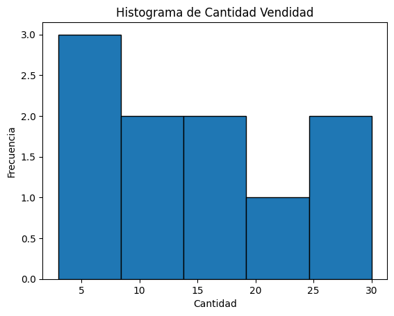

```python
# Gaficar un histograma usando Matplotlib
import matplotlib.pyplot as plt

plt.hist(df_tienda['Cantidad Vendida'], bins=5, edgecolor='black')
plt.title('Histograma de Cantidad Vendidad')
plt.xlabel('Cantidad')
plt.ylabel('Frecuencia')
plt.show()
```